# 12_GAN

**Generative Adversarial Networks (GAN)**

By Prof. Seungchul Lee  
http://iailab.kaist.ac.kr/  
Industrial AI Lab at KAIST

Table of Contents

Source

- 1시간만에 GAN(Generative Adversarial Network) 완전 정복하기
  - by 최윤제 (고려대 석사생)
  - YouTube: https://www.youtube.com/watch?v=odpjk7_tGY0
  - Slides: https://www.slideshare.net/NaverEngineering/1-gangenerative-adversarial-network
- CSC321 Lecture 19: GAN
  - By Prof. Roger Grosse at Univ. of Toronto
  - http://www.cs.toronto.edu/~rgrosse/courses/csc321_2018/
- CS231n: CNN for Visual Recognition
  - Lecture 13: Generative Models
  - By Prof. Fei-Fei Li at Stanford University
  - http://cs231n.stanford.edu/

# 1. Discriminative Model v.s. Generative Model

**Discriminative model**

A discriminative model learns the boundary between classes directly from data. Rather than understanding *what the data looks like*, it focuses on *how to tell them apart*. Formally, it models the conditional probability:

$$P(y \mid x)$$

where:

- $x$ : input data (e.g., an image)
- $y$ : class label (e.g., *man* or *woman*)

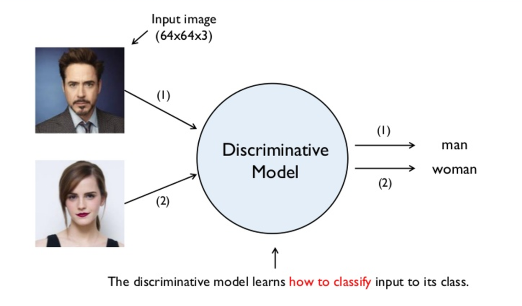

**Cenerative model**

A generative model learns the distribution of training data itself. Rather than learning to classify existing data, it learns *what the data looks like* — so that it can create new samples that resemble the training data. Formally, it models:

$$P(x) \quad \text{or} \quad P(x, y)$$

where $x$ is the data (e.g., an image) and $y$ is an optional class label.

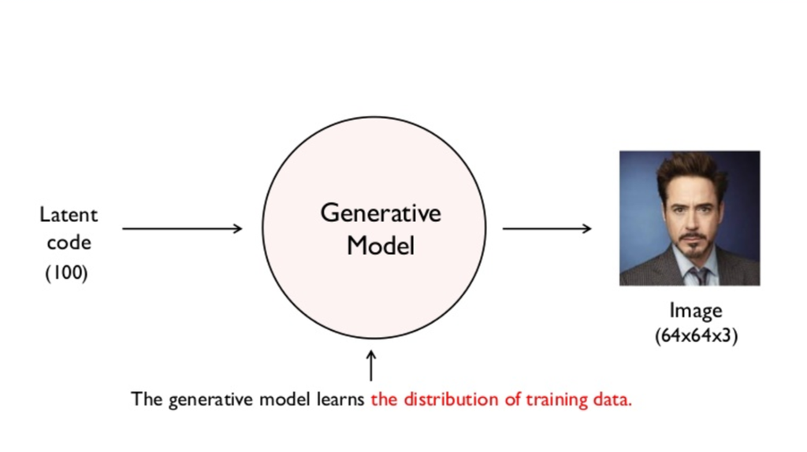

# 2. Probabilty Perspective of Generative Model

## 2.1. Probability Basics (Review)

Consider rolling a die. The outcome is not fixed in advance — it can be any value from 1 to 6. We call this outcome a random variable $X$.

For each possible value of $X$, we can assign a probability. This assignment is called a probability mass function (PMF):

$$P(X = x) \quad \text{for } x \in \{1, 2, 3, 4, 5, 6\}$$

The table shows one example. The value 4 never appears ($P(X=4) = 0$), and the value 6 appears twice as often as the others ($P(X=6) = \frac{2}{6}$). The remaining values each occur with probability $\frac{1}{6}$.

The bar chart visualizes this PMF. The height of each bar represents the probability of that outcome. Two properties always hold for any valid PMF:

$$ \begin{align*} P(X = x) &\geq 0 \quad \text{for all } x \\\\ \sum_{x} P(X = x) &= 1 \end{align*} $$

In practice, we estimate $P(X)$ by counting how often each outcome appears across many trials. As the number of trials increases, the empirical frequency converges to the true theoretical probability — this is the law of large numbers:

$$P(X = x) \approx \frac{\text{count}(X = x)}{N} \quad \text{as } N \to \infty$$

This is the discrete case — $X$ takes values from a finite set. When $X$ is continuous, the PMF is replaced by a probability density function (PDF), and the sum becomes an integral.

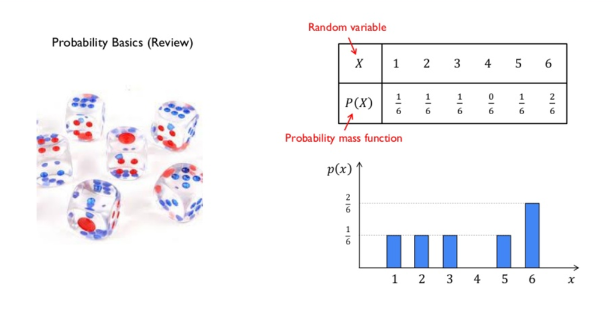

## 2.2. From Dice to Images

Now consider a very different kind of random variable. What if $x$ is an actual image from a training dataset? Each image can be represented as a $64 \times 64 \times 3$ dimensional vector — one value per pixel per color channel, giving 12,288 dimensions in total.

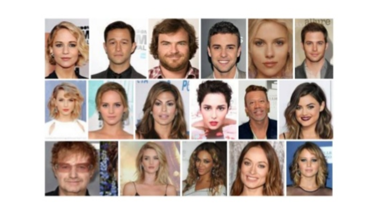

The images above are some realizations (samples) from this space. Each one is a single point in a 12,288-dimensional space, drawn from the unknown distribution $p_{\text{data}}(x)$.

Of course, not every point in this high-dimensional space corresponds to a realistic face. The vast majority of randomly chosen vectors would produce noise. The real face images occupy a very small, structured region of this space — and $p_{\text{data}}(x)$ assigns high probability density precisely to that region.

The goal of the generative model is to learn where that region is, and how probability mass is distributed within it — so that new samples drawn from $p_{\text{model}}(x)$ land in the same region and look like plausible face images.

This is essentially a probability density function estimation problem.

## 2.3. Probability Density Function of Data and Model

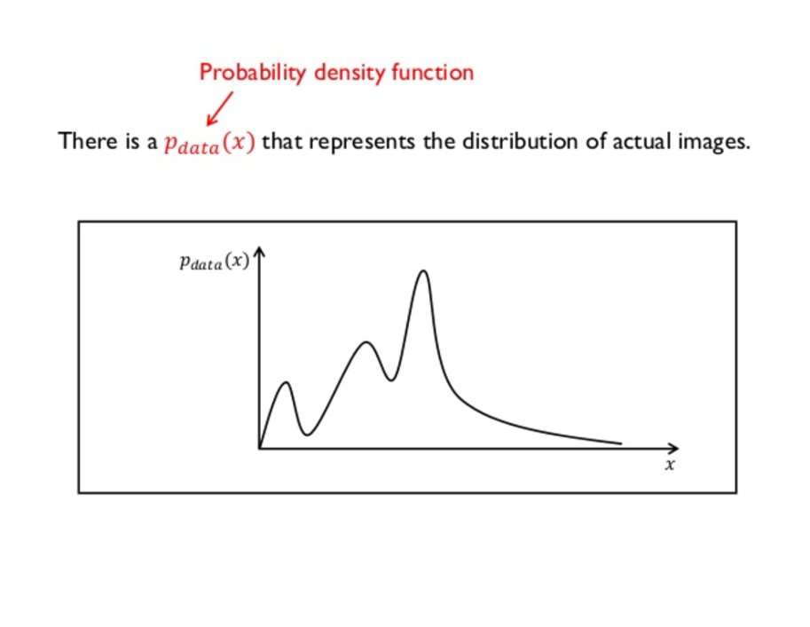

The first figure shows that there exists a true $p_{\text{data}}(x)$ — a probability density function that represents the distribution of actual images. This function is unknown and cannot be accessed directly. All we have is a finite set of samples drawn from it — the training images.

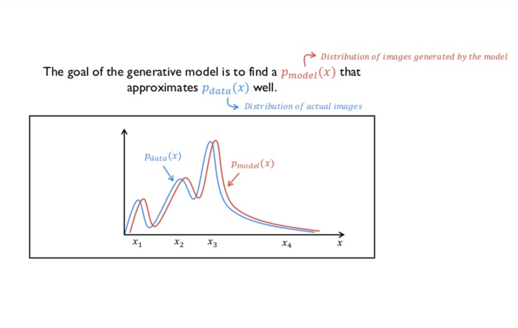

The second figure shows what we are trying to achieve. The goal is to find a $p_{\text{model}}(x)$ — the distribution of images generated by the model — that approximates $p_{\text{data}}(x)$ as closely as possible. If this approximation is good enough, then sampling from $p_{\text{model}}(x)$ will produce new images that are indistinguishable from real ones.

One way to measure how well $p_{\text{model}}(x)$ approximates $p_{\text{data}}(x)$ is the Kullback–Leibler (KL) Divergence:

$$D_{\text{KL}}(p_{\text{data}} \| p_{\text{model}}) = \int p_{\text{data}}(x) \log \frac{p_{\text{data}}(x)}{p_{\text{model}}(x)}\, dx$$

This quantity is zero when the two distributions are identical, and grows larger as they diverge. Training a generative model can be understood as minimizing this gap — pushing $p_{\text{model}}(x)$ progressively closer to $p_{\text{data}}(x)$ until the generated samples become realistic.

The key point is that $p_{\text{data}}(x)$ is unknown. We never have access to this function directly — we only have a finite set of samples drawn from it (the training dataset). The goal of a generative model is to learn $p_{\text{model}}(x)$ that approximates this unknown $p_{\text{data}}(x)$ closely enough that samples drawn from $p_{\text{model}}(x)$ are indistinguishable from real data.

## 2.4. How Does a Neural Network Represent a Probability Distribution?

A neural network is deterministic. Given the same input, it always produces the same output. So it does not represent a probability distribution the way one might first imagine.

One might think the network encodes $p_{\text{model}}(x)$ as a function — with input neurons receiving values of $x$ at regular intervals, and output neurons returning the corresponding density values. This is not what happens.

Instead, the idea is much simpler:

We already know how to sample from a simple distribution — a standard Gaussian $z \sim \mathcal{N} (0, I)$. We feed this sampled value $z$ into the network as input. The network then applies a deterministic transformation:

$$x = G(z)$$

Because $z$ is random, $x$ is also random. Different samples of $z$ produce different outputs $x$. The collection of all such outputs $\{G(z)\}$ follows some distribution — and that distribution is what we call $p_{\text{model}}(x)$.

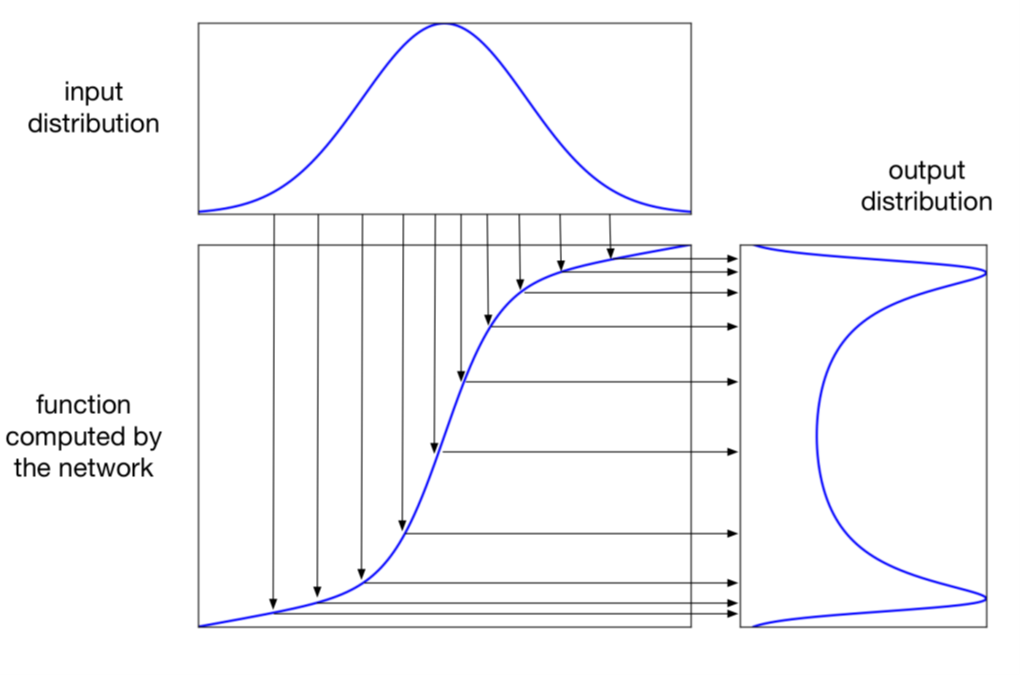

The network never explicitly computes or stores $p_{\text{model}}(x)$. The distribution exists only implicitly — as the statistical behavior of the outputs across many different inputs $z$. Training adjusts the parameters of $G$ so that this implicit output distribution matches $p_{\text{data}}(x)$ as closely as possible.

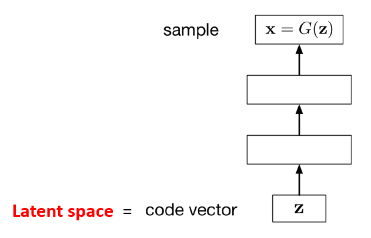

The target of this transformation is $p_{\text{data}}(x)$ — but $p_{\text{data}}(x)$ is never known explicitly. What we have instead is a finite set of samples drawn from it: the training images. These samples are the only evidence we have about what $p_{\text{data}}(x)$ looks like.

Training is therefore an indirect process. Rather than minimizing a distance to $p_{\text{data}}(x)$ directly, we adjust the parameters of $G$ so that the outputs $\{G(z)\}$ resemble the training samples as closely as possible. The assumption is that if the generated samples are statistically similar to the training data, then $p_{\text{model}}(x)$ must be close to $p_{\text{data}}(x)$.

The neural network is responsible for this nonlinear transformation. It does not receive any explicit description of $p_{\text{data}}(x)$ — it infers the appropriate mapping entirely from the training samples. This is what it means for a generative model to be data-driven.

**Generative model of high dimensional space**

The figure below illustrates the training process of a generative model in high-dimensional image space.

On the left, $z$ is sampled from a unit Gaussian — a simple, low-dimensional distribution that is easy to sample from. This vector is passed into the generative model (a neural network with parameters $\theta$), which applies a nonlinear transformation and produces a sample in image space.

The middle panel shows the generated distribution $\hat{p}(x)$ — the region of image space that the model currently covers. The right panel shows the true data distribution $p(x)$, which is never known explicitly. The black dots represent the training samples — the only observations we have of $p(x)$.

The "loss" connects the two panels. This is the key: training is driven by measuring the discrepancy between $\hat{p}(x)$ and the training samples, and using that signal to update $\theta$. The parameters of the network are adjusted iteratively so that the generated distribution $\hat{p}(x)$ moves closer to $p(x)$.

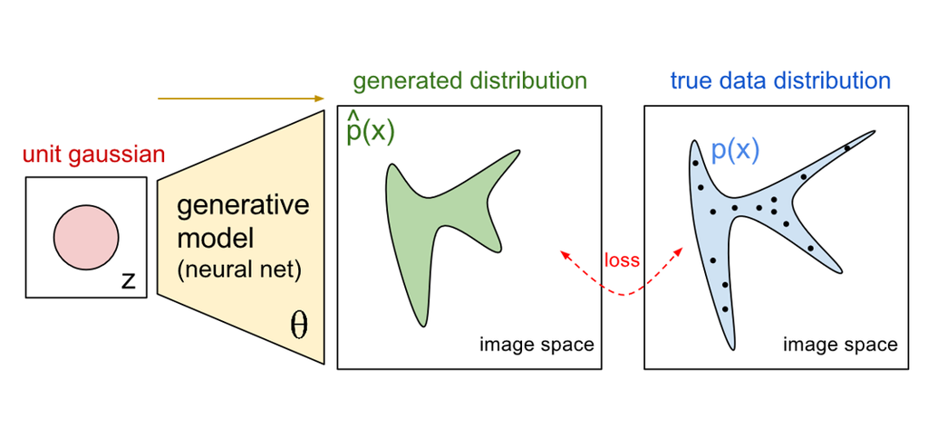

**Generating Images After Training**

Once the generative model is trained, generating a new image is straightforward.

Each dimension of the code vector $z$ is sampled independently from a simple distribution — such as a Gaussian or uniform distribution. This vector is then fed into the deterministic generator network, which outputs a new image.

The key point is that the entire mapping — from independent Gaussian noise all the way to a coherent image — is learned from data. After training, the network has encoded the structure of the training distribution into its parameters $\theta$, and a single forward pass through the network is all that is needed to produce a new sample.

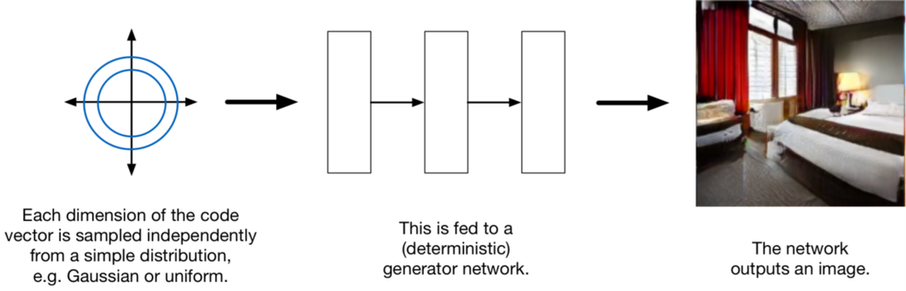

Measuring the discrepancy between $\hat{p}(x)$ and the training samples is challenging. How should we define and compute this discrepancy in a way that is both meaningful and computationally tractable?

[Ian Goodfellow](https://en.wikipedia.org/wiki/Ian_Goodfellow) came up with a great idea for measuring the discrepancy between $\hat{p}(x)$ and $p_{\text{data}}(x)$, and developed GAN — Generative Adversarial Network. The original paper, "Generative Adversarial Nets," was published in 2014 while Goodfellow was a PhD student at the Université de Montréal under the supervision of [Yoshua Bengio](https://en.wikipedia.org/wiki/Yoshua_Bengio). The story behind the idea is well known in the deep learning community: Goodfellow conceived the core concept of the adversarial framework in a single evening and implemented a working prototype the same night. The paper has since become one of the most cited works in the history of deep learning, and [Yann LeCun](https://en.wikipedia.org/wiki/Yann_LeCun), one of the pioneers of the field, described GAN as "the most interesting idea in the last ten years in machine learning." We will study it in the following session.

# 3. Generative Adversarial Networks (GAN)

In generative modeling, we would like to train a network that models a distribution over data — such as a distribution over images. As discussed, this requires measuring the discrepancy between the generated distribution $\hat{p}(x)$ and the true data distribution $p_{\text{data}}(x)$, which is challenging to do explicitly.

GANs take a fundamentally different approach: they do not work with any explicit density function at all. Instead, they adopt a game-theoretic approach — measuring the quality of the generator indirectly, through the judgment of a second network.

## 3.1. Adversarial Nets Framework

One natural way to judge the quality of a generative model is to sample from it and ask: do these samples look real? This is exactly the criterion GANs operationalize.

The goal is to train a generator network to produce samples which are indistinguishable from real data, as judged by a discriminator network whose job is to tell real from fake.

GAN trains two networks simultaneously and in opposition:

- The discriminator network $D$ takes an image as input and outputs the probability that it came from the real data distribution. It is trained to correctly classify real images as real and generated images as fake.
- The generator network $G$ takes a noise vector $z \sim \mathcal{N}(0, I)$ as input and outputs a synthetic image $G(z)$. It is trained to produce realistic-looking samples that fool the discriminator into believing they are real.

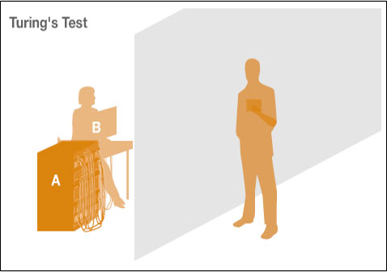

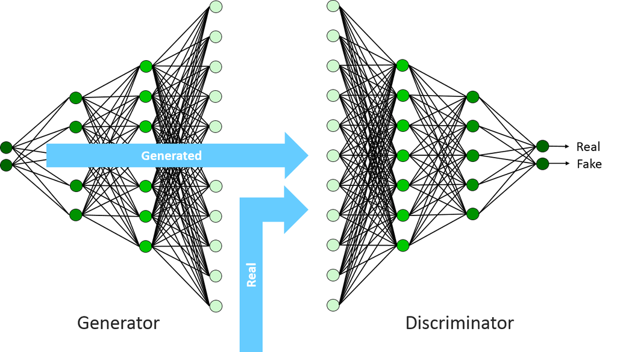

## 3.2. GAN in Detail

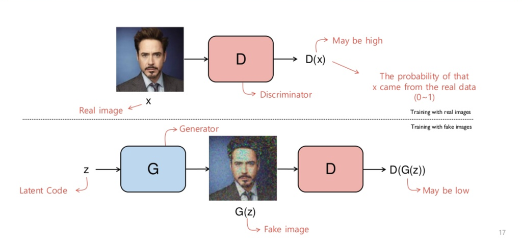

**Discriminator Network**

The discriminator $D$ is a neural network that takes an image as input and outputs a single scalar value $D(x) \in [0, 1]$, representing the probability that the input image is real.

The figure illustrates the first half of the adversarial framework. A real image $x$ of size $64 \times 64 \times 3$ is fed into the discriminator. The discriminator should classify a real image as real — meaning its output $D(x)$ should be close to 1.

The discriminator is trained with two types of inputs:

- Real images sampled from the training data, for which the target output is 1
- Fake images $G(z)$ produced by the generator, for which the target output is 0

The bottom row of the figure (shown faded) previews the generator side of the framework — a noise vector $z$ is passed through the generator $G$ to produce a fake image $G(z)$, which is then also passed into the discriminator to produce $D(G(z))$. This value should be close to 0 from the discriminator's perspective.

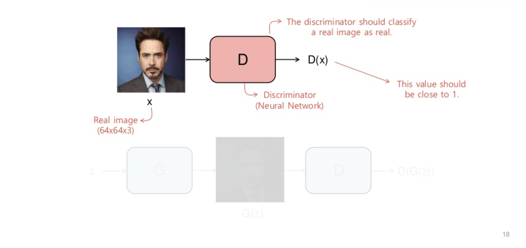

[figure not shown]

**Generator Network**

The generator $G$ is a neural network that takes a latent code $z$ as input and produces a synthetic image $G(z)$.

The generator's goal is to create an image that is indistinguishable from real data — to deceive the discriminator into believing that $G(z)$ is a real image. From the generator's perspective, the output $D(G(z))$ should be close to 1.

This is the opposite of what the discriminator wants. The discriminator tries to push $D(G(z))$ toward 0, while the generator tries to push it toward 1. This tension is what drives the adversarial training process.

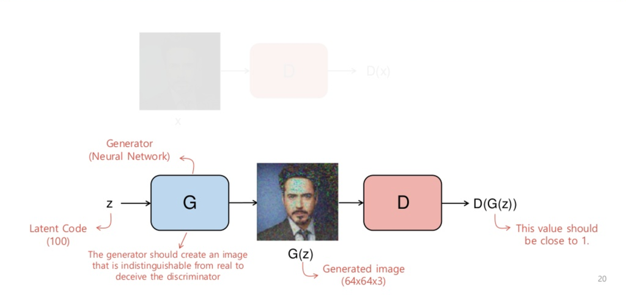

## 3.3. Loss Function of GAN

The GAN objective can be derived from a familiar starting point — the binary cross-entropy loss used in logistic regression:

$$\text{loss} = -y \log h(x) - (1-y) \log (1-h(x))$$

where $y \in \{0, 1\}$ is the true label and $h(x)$ is the predicted probability.

The discriminator is essentially a binary classifier that assigns label $y = 1$ to real images and $y = 0$ to fake images. Applying the cross-entropy loss to both cases and taking expectations gives the discriminator's objective:

$$\max_D \; \mathbb{E}_{x \sim p_{\text{data}}} [\log D(x)] + \mathbb{E}_{z \sim p(z)} [\log (1 - D(G(z)))]$$

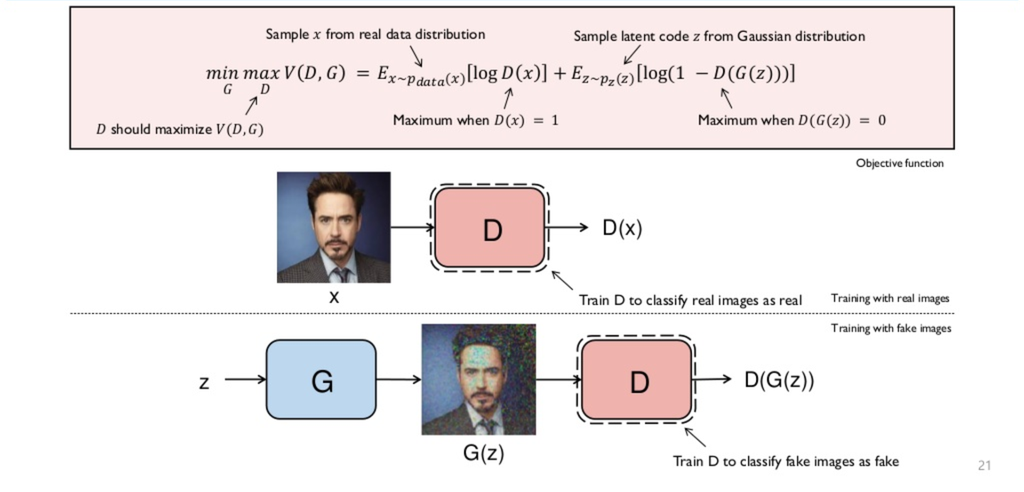

The generator's objective is the opposite — it wants to fool the discriminator, so it minimizes the same expression with respect to its own parameters:

$$\min_G \; \mathbb{E}_{z \sim p(z)} [\log (1 - D(G(z)))]$$

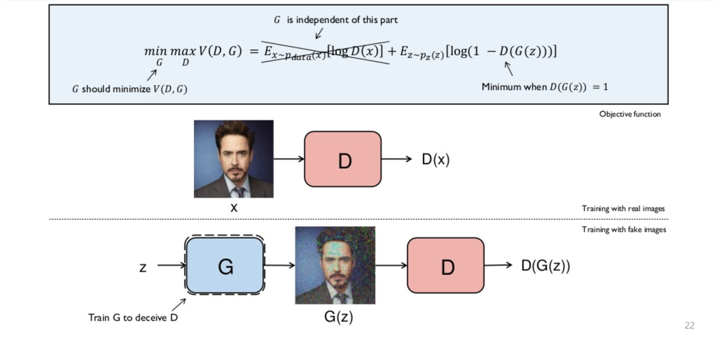

However, this formulation causes a practical problem known as saturation. Early in training, when $G$ is poor, the discriminator can reject generated samples with high confidence because they are clearly different from real data. In this regime, $D(G(z)) \approx 0$, and $\log(1 - D(G(z))) \approx 0$, which means the gradient flowing back to $G$ is near zero — the generator receives almost no learning signal.

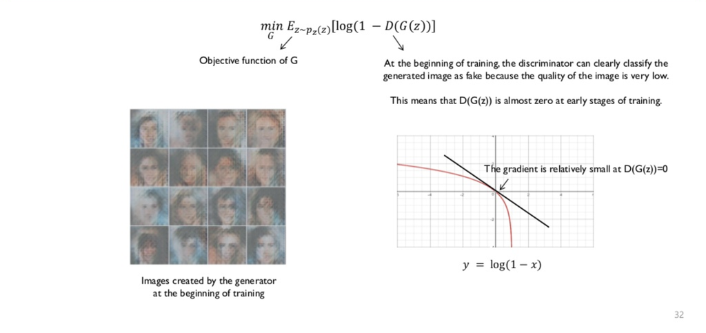

To address this, rather than training $G$ to minimize $\log(1 - D(G(z)))$, we instead train $G$ to maximize $\log D(G(z))$:

$$\max_G \; \mathbb{E}_{z \sim p(z)} [\log D(G(z))]$$

This is called the non-saturating game. The two objectives — $\min \log(1-D(G(z)))$ and $\max \log D(G(z))$ — have the same fixed point in theory, but the non-saturating version provides much stronger gradients early in learning, when the generator needs them most.

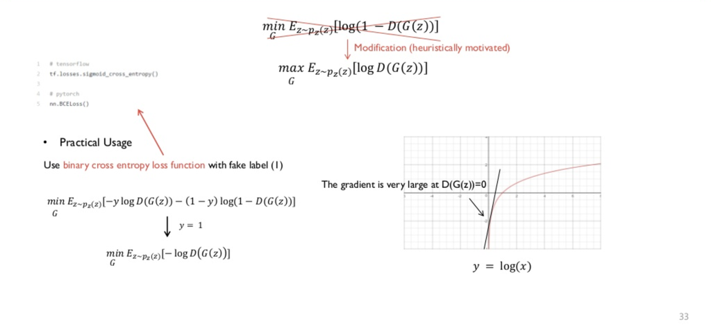

## 3.4. Soving a MinMax Problem

Training a GAN requires optimizing two networks simultaneously — which raises an immediate question: how do we train two networks that have opposing objectives? The answer is to alternate between them. Rather than updating $G$ and $D$ at the same time, we fix one and update the other, then swap. This turns the minimax problem into a sequence of standard gradient steps.

Step 1: Fix $G$ and perform a gradient step to update $D$:

$$\max_{D} \; \mathbb{E}_{x \sim p_{\text{data}}(x)}\left[\log D(x)\right] + \mathbb{E}_{z \sim p_{z}(z)}\left[\log (1-D(G(z)))\right]$$

Step 2: Fix $D$ and perform a gradient step to update $G$:

$$\max_{G} \; \mathbb{E}_{z \sim p_{z}(z)}\left[\log D(G(z))\right]$$

Since most deep learning frameworks are built around minimization, the equivalent formulation using gradient descent is:

Step 1: Fix $G$ and perform a gradient step to update $D$:

$$\min_{D} \; \mathbb{E}_{x \sim p_{\text{data}}(x)}\left[-\log D(x)\right] + \mathbb{E}_{z \sim p_{z}(z)}\left[-\log (1-D(G(z)))\right]$$

Step 2: Fix $D$ and perform a gradient step to update $G$:

$$\min_{G} \; \mathbb{E}_{z \sim p_{z}(z)}\left[-\log D(G(z))\right]$$

These two formulations are equivalent — the second is simply the first with the sign flipped, expressing the same optimization in terms of minimization rather than maximization. In practice, the two steps are repeated alternately for each mini-batch throughout training.

# 4. GAN with MNIST

To make the concepts from the previous sections concrete, we will implement a GAN from scratch and observe how it behaves in practice. To keep things simple, we will train a GAN to generate images of the digit 2 from the MNIST dataset, using basic fully-connected neural networks (ANN) for both the generator and the discriminator.

## 4.1. GAN Implementation

```python
import tensorflow as tf
import numpy as np
import matplotlib.pyplot as plt
%matplotlib inline
```

```python
(train_x, train_y), _ = tf.keras.datasets.mnist.load_data()

train_x = train_x[np.where(train_y == 2)]
train_x = train_x/255.0
train_x = train_x.reshape(-1, 784)

print('train_iamges :', train_x.shape)
```

```
train_iamges : (5958, 784)
```

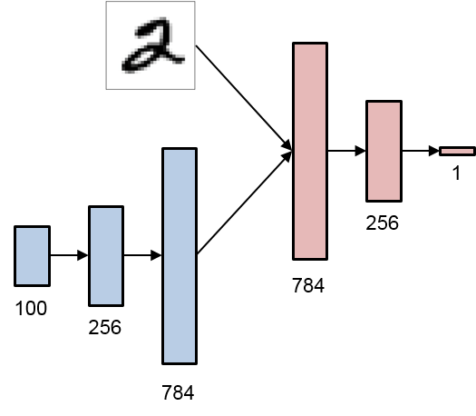

```python
generator = tf.keras.models.Sequential([
    tf.keras.layers.Dense(units = 256, activation = 'relu', input_dim = 100),
    tf.keras.layers.Dense(units = 784, activation = 'sigmoid')
])
```

```python
discriminator = tf.keras.models.Sequential([
    tf.keras.layers.Dense(units = 256, activation = 'relu', input_dim = 784),
    tf.keras.layers.Dense(units = 1, activation = 'sigmoid'),
])
```

```python
discriminator.compile(optimizer = tf.keras.optimizers.Adam(learning_rate = 0.0001),
                      loss = 'binary_crossentropy')
```

Note that `discriminator.trainable = False` is set before building the `combined` model. This ensures that when training the `combined` model, only the generator's parameters are updated. If this were not set, the discriminator's parameters would also change during the generator update step, which would break the adversarial training process.

The `combined` model chains the generator and the discriminator together: it takes a noise vector as input, passes it through the generator to produce a fake image, and then passes that image through the (frozen) discriminator to produce a scalar output. This allows gradients to flow back through the discriminator and into the generator during training.

```python
discriminator.trainable = False

combined_input = tf.keras.layers.Input(shape = (100,))
generated = generator(combined_input)
combined_output = discriminator(generated)

combined = tf.keras.models.Model(inputs = combined_input, outputs = combined_output)
```

```python
combined.compile(optimizer = tf.keras.optimizers.Adam(learning_rate = 0.0002),
                 loss = 'binary_crossentropy')
```

The `make_noise` function samples from a standard Gaussian distribution $\mathcal{N}(0, 1)$ to produce the latent code $z$. Since each dimension is sampled independently from the same distribution, this is white noise — and that is why the function is named `make_noise`.

```python
def make_noise(samples):
    return np.random.normal(0, 1, [samples, 100])
```

```python
def plot_generated_images(generator, samples = 3):

    noise = make_noise(samples)

    generated_images = generator.predict(noise)
    generated_images = generated_images.reshape(samples, 28, 28)

    for i in range(samples):
        plt.subplot(1, samples, i+1)
        plt.imshow(generated_images[i], 'gray', interpolation = 'nearest')
        plt.axis('off')
        plt.tight_layout()

    plt.show()
```

Since GAN has two networks, we train their parameters alternatively — fixing one while updating the other.

Step 1: Fix $G$ and perform a gradient step to update $D$:

$$\min_{D} \; \mathbb{E}_{x \sim p_{\text{data}}(x)}\left[-\log D(x)\right] + \mathbb{E}_{z \sim p_{z}(z)}\left[-\log (1-D(G(z)))\right]$$

Step 2: Fix $D$ and perform a gradient step to update $G$:

$$\min_{G} \; \mathbb{E}_{z \sim p_{z}(z)}\left[-\log D(G(z))\right]$$

```
Discriminator Loss:  1.873877376317978
Generator Loss:  0.338532954454422
```

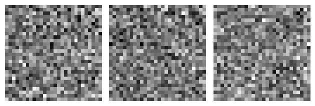

```
Discriminator Loss:  0.18016396462917328
Generator Loss:  2.5140249729156494
```

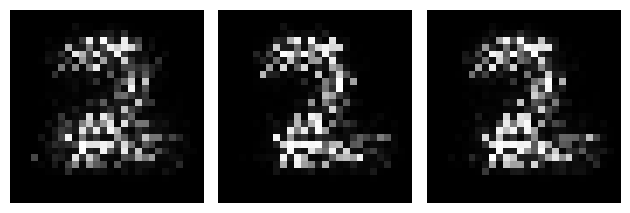

```
Discriminator Loss:  0.44247880578041077
Generator Loss:  2.2012200355529785
```

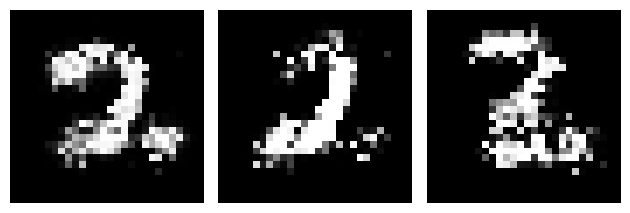

```
Discriminator Loss:  0.5620711445808411
Generator Loss:  2.061182975769043
```

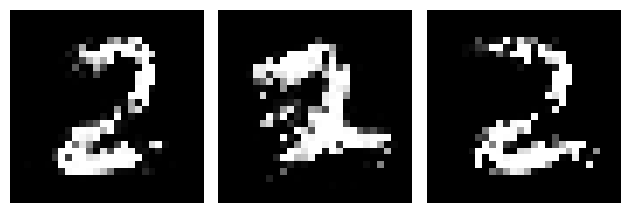

```python
n_iter = 20000
batch_size = 100

fake = np.zeros(batch_size)
real = np.ones(batch_size)

for i in range(n_iter):

    # Train Discriminator
    noise = make_noise(batch_size)
    generated_images = generator.predict(noise, verbose = 0)

    idx = np.random.randint(0, train_x.shape[0], batch_size)
    real_images = train_x[idx]

    # update D's parameters
    D_loss_real = discriminator.train_on_batch(real_images, real)
    D_loss_fake = discriminator.train_on_batch(generated_images, fake)
    D_loss = D_loss_real + D_loss_fake

    # Train Generator (update G's parameters)
    noise = make_noise(batch_size)
    G_loss = combined.train_on_batch(noise, real)

    if i % 5000 == 0:

        print('Discriminator Loss: ', D_loss)
        print('Generator Loss: ', G_loss)

        plot_generated_images(generator)
```

## 4.2. After Training

After training, we no longer need the discriminator. We use only the generator network to produce new images. By sampling a noise vector $z \sim \mathcal{N}(0, 1)$ and passing it through the trained generator, we can generate new images that resemble the training data.

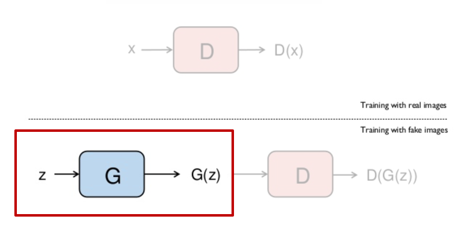

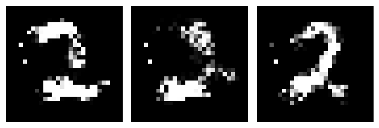

```python
plot_generated_images(generator)
```

# 5. Conditional GAN (cGAN)

A standard GAN learns to generate samples from $p_{\text{data}}(x)$ without any control over what is generated. Each sample $G(z)$ is drawn randomly from whatever distribution the generator has learned — there is no way to specify what kind of image should be produced.

Conditional GAN addresses this limitation by conditioning both the generator and the discriminator on additional information $c$, such as a class label.

$$G(z, c) \rightarrow \hat{x} \qquad D(x, c) \rightarrow [0, 1]$$

The conditioning information $c$ is provided as an additional input to both networks. This allows the generator to produce samples that correspond to a specific class, and the discriminator to evaluate not just whether an image looks real, but whether it looks real given the specified condition.

The objective function is a straightforward extension of the original GAN objective:

$$\min_G \max_D \; \mathbb{E}_{x \sim p_{\text{data}}(x|c)}\left[\log D(x, c)\right] + \mathbb{E}_{z \sim p_{z}(z)}\left[\log (1 - D(G(z, c), c))\right]$$

The only difference from the unconditional case is that every term is now conditioned on $c$. The generator learns $p_{\text{model}}(x \mid c)$ rather than $p_{\text{model}}(x)$ — the distribution of images given a particular condition.

The conditioning variable $c$ can take many forms in practice:

- a class label (e.g., generate an image of a cat)
- a text description (e.g., generate an image from a caption)
- another image (e.g., image-to-image translation)
- any auxiliary information available at training time

This simple modification transforms GAN from an uncontrolled sampler into a controllable generative model, making it applicable to a much broader range of tasks.

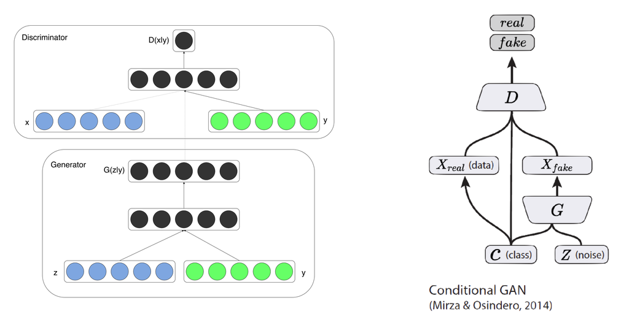